# Park Analysis 4 PA Models

In Woo Park

3/05/2021

### Introduction

In this document we analyze natural networks through plotting degree distributions, fitting distributions to the power law, and modeling with preferential attachment models. The objective is to identify real world processes and constraints that may have generated the networks.

### Part A. Analyzing and Interpreting the Structure of a Real World Network

In this section, we use our analytic toolkit to characterize a natural network.

#### Western States Power Grid

Below we read in an undirected unweighted representation of the topology of the Western States Power Grid of the United States, compiled by Duncan Watts and Steven Strogatz. The network was taken from the web site of Prof. Watts at Columbia University (http://cdg.columbia.edu/cdg/datasets, but this site is no longer available). It was used as one example in: D. J. Watts and S. H. Strogatz, “Collective dynamics of `small-world’ networks”, Nature 393, 440-442 (1998). We presume that the nodes are major generators and distribution centers and the edges are the physical power lines connecting them, often over long distances at great expense.

```r
PG <- read_graph("Networks/power_grid.gml", format="gml")
summary(PG)
```

```
IGRAPH 0786bf5 U--- 4941 6594 --
+ attr: id (v/n)
```

#### 1. Network Visualization (5 pts)

**(a)** A full network visualization generated in Gephi is available in: Images/q1a.png. The layout algorithm used was ForceAtlas 2 with LinLog mode and set Gravity to make it sufficiently spread out that one can see the structure but not so spread out that it makes poor use of the space available A lower resolution version is reproduced below.

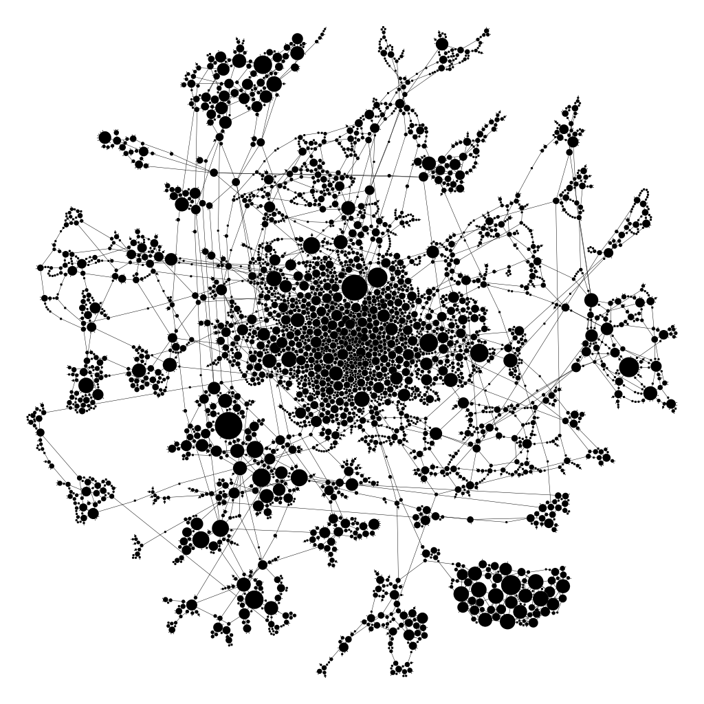

**(b)** Discussion of salient feature(s):

When visualizing a power grid, I would use mnemonics to determne salient features. In the visualization above, the graph has a huge cluster of nodes with smaller clusters surrounding it. If we compared it to the Western States of the United States, I would assume the center would represent a densely populated area such as a major state with a popular city (i.e. California: Los Angeles, San Fransisco) whilst the clusters surrounding it would represent other states with not as much population density (i.e. Utah). The smaller clusters usually have 2 to 3 additional ways of connecting to other clusters, which would suggest that it represents power line redundancies in case the connecting lines to the main grid fails. They have 2-3 other lines that allows them to connect to the grid. The super outliers could also just be suburban/rural areas as well, not necessarily representing states.

#### 2. Configuration Model and Metrics (8 pts)

**(a)** We construct a configuration model for this network in order to help us assess which metric features may be due to degree sequence alone rather than other wiring constraints. The Viger-Latapy method is used to provide a simple undirected graph.

```r
summary(PG.config)
```

```
IGRAPH 12d1d66 U--- 4941 6594 -- Degree sequence random graph
+ attr: name (g/c), method (g/c)
```

**(b)** Standard metrics are computed on and compared between the configuration model and the natural network below.

Mean degree and log(|V|) enable us to compare to random graph regimes:

| MeanDegree | log\|V\| |
| --- | --- |
| 2.669095 | 8.505323 |

Other metrics enable us to compare the natural network to the configuration model:

[output not shown]

```r
PG.metrics1

PG.metrics2
```

| Degree Correlation PG | Degree Correlation PG.config |
| --- | --- |
| 0.003456988 | -0.00319069 |

```r
PG.metrics3
```

| Mean Distance PG | Mean Distance PG.config |
| --- | --- |
| 18.98919 | 8.687886 |

```r
table(components(PG.config)$csize)
```

```
4941
   1
```

#### 3. Degree Distribution (4 pts)

Linear binned and cumulative plots of degree distribution are provided below, along with minimum and maximum degree.

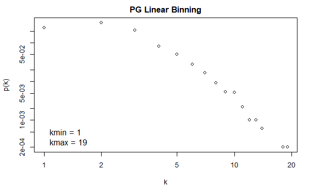

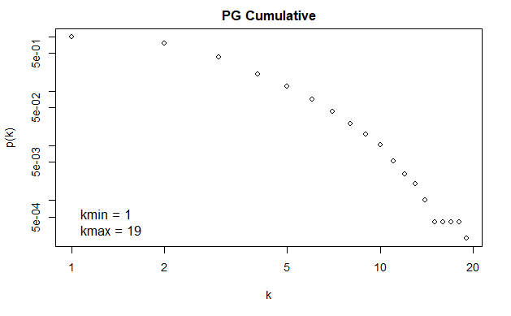

```r
quickplot1(PG)
plfit_legend(PG)

quickplot2(PG)

plfit_legend(PG)
```

#### 4. Fitting to Power Law (5 pts)

The results of fit_power_law are provided below.

| continuous | alpha | xmin | logLik | KS.stat | KS.p |
| --- | --- | --- | --- | --- | --- |
| FALSE | 7.629416 | 10 | -79.90638 | 0.02860761 | 1 |

| continuous | alpha | xmin | logLik | KS.stat | KS.p |
| --- | --- | --- | --- | --- | --- |
| FALSE | 1.795673 | 1 | -10258.33 | 0.2813235 | 0 |

The original tibble shows that the power law fits for xmin = 10. For the second tibble, we show that using xmin = 1 instead of 10 that the probability of fitting a power law drops to 0.

#### 5. Discussion (8 pts)

**(a) Connectivity:** Comparing mean degree `2.7` to log(|V|) `8.5`, we see that the G(n,m) random model (Barabasi Figure 3.7) predicts Supercritical Regime, obviously different from the power grid. This difference can be attributed to random network models predicting that isolated nodes and tiny components observed for small collapse into a giant component through a phase transition. The power grid should be a giant component that is fully connected.

**(c) Transitivity and Small Degree Saturation:** Compared to the random models, the power grid has really high transitivity and not so much small degree saturation. This difference results from the power grid showing that some areas probably has a higher population density than other areas. In our case, a certain city in a popular state, (i.e. LA) would have a clear higher population density than another city from the same state (i.e. Tustin), this could suggest why there is a disparity.

### Part B. Modeling the Degree Distribution of a Real World Network

In this section, we model the degree distribution of a natural network with variations of the Preferential Attachment model, with particular attention paid to what features of the degree distribution are predicted by domain processes, and whether we can replicate observed featurs with Preferential Attachment variants.

#### High-Energy Physics Citation Network

Below we read in a graph of citations in the High Energy Physics theory arXiv from January 1993 to April 2003. If a paper i cites paper j, the graph contains a directed edge from i to j. Thus, in-degree indicates how many other papers chose to cite a given paper over time, while out-degree indicates how many papers a given paper cites at publication time. We analyze these distributions separately as they are driven by distinct processes, as discussed below.

```r
HEP <- read_graph("Networks/cit-HepTh.gml", format="gml")
HEP <- read_graph("Networks/cit-HepTh.gml", format="gml")
summary(HEP)
```

```
IGRAPH d2b0390 D--- 27770 352807 --
+ attr: id (v/n), id (e/n), value (e/n)
```

#### 6. Discussion of Domain Processes (12 pts)

For each of the following, we consider whether or not domain processes are expected to exhibit growth, preference of attachment based on degree, nonlinearity in this preference of attachment, initial appeal, and/or preferences sensitive to aging.

**(a) In-Degree (being cited):**

Growth for in-degrees make sense because in random network models, we assume that the number of nodes N is fixed. Obviously, paper citations since 1993 to 2003 means that for each year, there is more nodes added to the network. Growth processes continuously increase N.Preferential Attachment also makes sense because papers will usually cite each others work if they are working in the same area of interest and because it is a real network, there are papers that will be more popular than others that are cited. For nonlinearity in this preference of attachment, I would expect it to follow the Linear Regime of (alpha = 1) because it must follow a power law based on these domain processes as a real network. Fitness for sure makes sense because in Barabasi 6.3 they mention that while most research papers acquire only a few citations, a small number of publications collect thousand and even tens of thousands of citations. Initial Appeal or attractiveness obvious can play a role because it doesn’t make sense where there could be an academic journal where it has no connections with. You can argue that two papers that are new that have no unique citations still have a chance of citing each other if they are related in the same topic. To allow unconnceted nodes to acquire links we add a constant to the preferential attachment. Citation based on age, not that it means that because your paper is old, other papers WILL cite you, it’s more like the probability is higher for papers to cite you because your old, there is no guarantee.

**(b) Out-Degree (citing others):**

Growth, I’m not sure if growth would affect out-degree as much because once a paper is written with that current eras citations, new papers that come out next year won’t really be cited in the old work. Preference of attachment, definitely because if a paper is written, there must have been a paper written prior that was objectively more popular which you also probably cited. Nonlinearity in this preference of attachment, similar to in-degree I think because the network is real it probably will follow the power law and therefore be another Linear Regime of (alpha = 1). Fitness: High fitness nodes are rare but not impossible. Because we assume it’s a real network and therefore follows a power law, there must be some instance of fitness that would influence the out-degree of citation nodes. Initial Appeal: Citations that are more grounded in research and more popular will have a higher weight in initial appeal. If your paper is on a similar topic you are more likely to cite them. Aging definitely because of the above explanation, if a certain citation is more popular, it had more time to marinate and be popular. Therefore you’re more likely to cite them.

**(c) Applicability of Preferential Attachment Models:** Given the above discussion, we expect that a preferential attachment model is a plausible model for **in-degree** because it makes sense that because higher-degree nodes (people citing you), have more visibility hence why others will most likely link to you. We expect that a preferential attachment model is also a plausible model for **out-degree** because other papers that have higher visibility makes you more like to connect to them.

#### 7. HEP Degree Distributions and Metrics (12 pts)

**(a) Degree Distribution Plots**

In-degree:

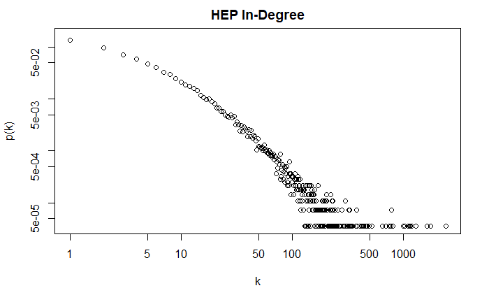

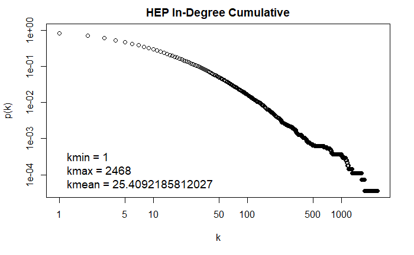

```r
plot(degree_domain(HEP, mode="in"),
     degree_distribution(HEP, mode="in"),
     log="xy", xlab="k", ylab="p(k)",
     main="HEP In-Degree")


quickplot3 <- function(g, main=g$name, cumulative=TRUE) {
  plot(degree_domain(g, mode="in"), degree_distribution(g, mode="in", cumulative = cumulative),
       log="xy", xlab="k", ylab="p(k)",
       main="HEP In-Degree Cumulative")
}

plfit_legend <- function(g) {
  g.plfit <- fit_power_law(degree(g), implementation="plfit")
  legend("bottomleft", bty="n", cex=1.2,
         c(paste("kmin =", min(degree(g))),
           paste("kmax =", max(degree(g))),
           paste("kmean =", mean(degree(g)))
         ))
}

quickplot3(HEP)

plfit_legend(HEP)
```

Out-degree:

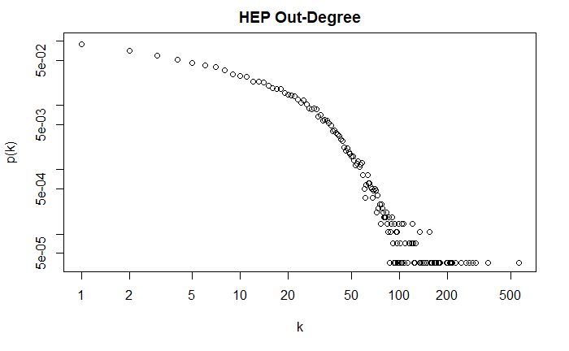

[figure not shown]

```r
plot(degree_domain(HEP, mode="out"),
     degree_distribution(HEP, mode="out"),
     log="xy", xlab="k", ylab="p(k)",
     main="HEP Out-Degree")

quickplot4 <- function(g, main=g$name, cumulative=TRUE) {
  plot(degree_domain(g, mode="out"), degree_distribution(g, mode="out", cumulative = cumulative),
       log="xy", xlab="k", ylab="p(k)",
       main="HEP Out-Degree Cumulative")
}

plfit_legend <- function(g) {
  g.plfit <- fit_power_law(degree(g), implementation="plfit")
  legend("bottomleft", bty="n", cex=1.2,
         c(paste("xmin =", HEP.plfit$xmin),
           paste("alpha =", HEP.plfit$alpha),
           paste("KS.p =", HEP.plfit$KS.p),
           paste("KS.stat =", HEP.plfit$KS.stat)
         ))
}

quickplot4(HEP)

plfit_legend(HEP)
```

**(b) Proposed Explanations of Observed In-Degree Distribution:**

Growth must be present because the nodes are not fixed and throughout the years we see a more papers being added to the network. The top most nodes in the figure would indicate the most recent papers because they are cited less and the bottom most nodes are cited the most. This would correlate with the other domain processes such as aging, preference of attachment, and initial appeal. This is also attributed to the fact that the most cited in-degree nodes are at the end of the graph and there is a large disparity of thickness meaning that each of these domain processes are playing a role in making sure the popular papers stay popular. The super critical regime and fitness however is hard to interpret. I believe this is due to my inexperience with theoretical graph analysis but I would suggest that with my experience, I am not able to determine if they exist.

**(c) Proposed Explanations of Observed Out-Degree Distribution:**

Similarly, the out-degree graph follows a similar graph visualization. I would suggest similar domain processes acting in this scenario as well. Growth seems to be present because as the network grows, the least cited papers will usually be the newest ones on the top left. This would then tie in to explaining why aging, preference of attachment, and initial appeal also influences the out-degree nodes because as papers are older, they have had more time for papers to cite to. In the case of some node, you are more likely to cite other works if they are older, has more citations prior (popular nodes), and has some initial appeal because a lot of other papers cite that particular paper. Similarly, I don’t have enough experience to see how fitness or super critical regime would exist from this graph other than the fact it looks like a figure barbasi chapter 6 would show so that is my own limitation.